# COMPSCIX 415.2 Homework 2

### 3.6.1 Exercises

**Q:** What geom would you use to draw a line chart? A boxplot? A histogram? An area chart?

1. *geom_line* is used for line chart.
2. *geom_boxplot* is used for boxplot.
3. *geom_histogram* is used for histogram.
4. *geom_area* is used for area chart.

**Q:** Run this code in your head and predict what the output will look like. Then, run the code in R and check your predictions.

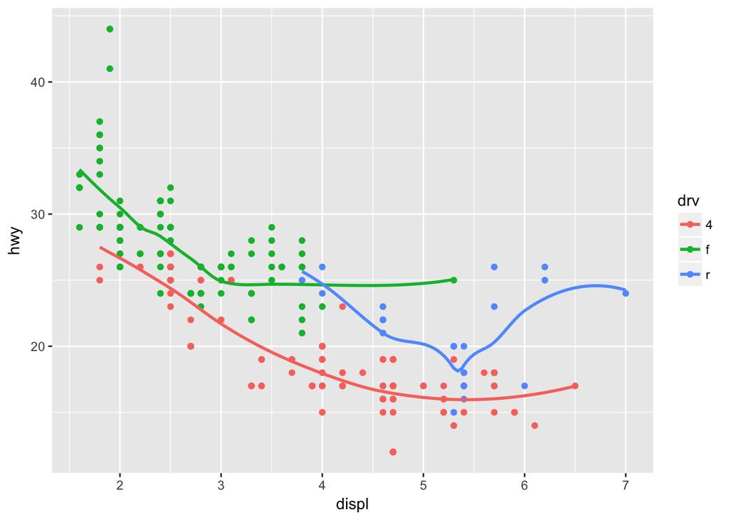

```r
ggplot(data = mpg, mapping = aes(x = displ, y = hwy, color = drv)) +
  geom_point() +
  geom_smooth(se = FALSE)
```

**Q:** What does show.legend = FALSE do? What happens if you remove it? Why do you think I used it earlier in the chapter?

*show.legend = FALSE* will turn off the legend that explains the mapping between the aesthetic level and values. When the legend is turned off it is impossible to make the aesthetic level to a value in data-frame. legend is set to *FLASE* early in the chapter to show how group aesthetic works.

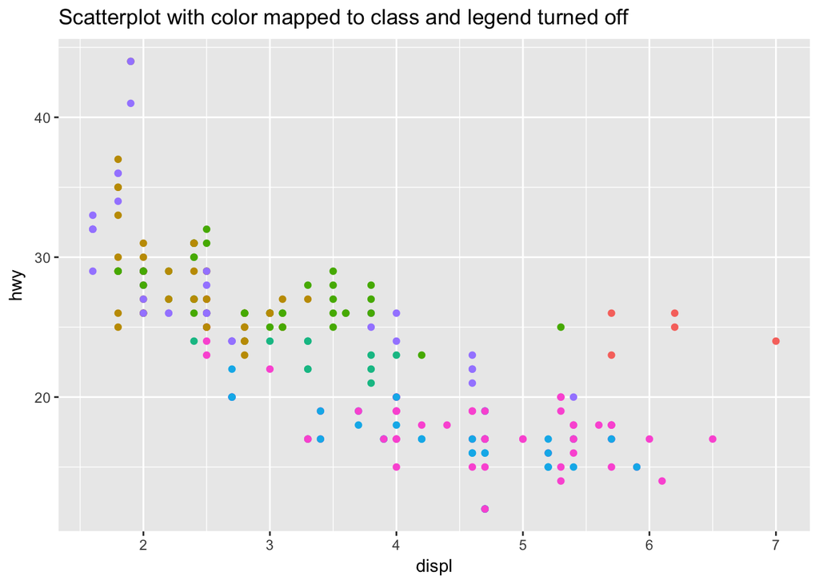

```r
ggplot(data = mpg) +
   geom_point(mapping = aes(x = displ, y = hwy, color = class) , show.legend = FALSE ) + labs(title = "Scatterplot with color mapped to class and legend turned off")
```

**Q:** What does the se argument to geom_smooth() do?

se controls the display of confidence interval around smooth.

**Q:** Will these two graphs look different? Why/why not?